# Report 1

Andreas Olden

January 21, 2019

## Report 1 written in R Markdown

[For Basic Markdown syntax checkout this website](https://www.markdownguide.org/basic-syntax/) [For one that is more comprehensive (you might not want to start here, even though you will end up here)](https://bookdown.org/yihui/rmarkdown/)

### What Markdown is and isn’t

Somewhat simplified, a markdown document consists of a YAML-code initiating the document. This part of the code is not shown in the output and contains title, author, date and output format. Then, typically you have an r-setup chunck which initates some global options. Then you have a combination of text, code, and the output of that code, be it tables or figures.

Before we begin creating a report it is good to think of what a notebook or rmarkdown file is and what it isn’t. Markdown creates great reports and presentations in HTML format. It is easy to include r-code, so that text and code and output can exist side by side. Markdown is super-easy to type set, and is a great way to explore and communicate data in virtually no time. It is however, not the greatest tool for writing dissertation type articles etc.. Latex, or even word or Google Docs give you much more control over typesetting, more flexibility, better citations and will be less hacky. Dont take my word for it, but check this reply on [Stackexchange](https://tex.stackexchange.com/questions/418962/markdown-vs-latex-for-thesis). The Stackexchange post offers some solutions, but in my experience it will be hacky or time consuming. I would skip the integration and create great, reproducible reports with Markdown, no hacky solutions, and use a different tool for writing my thesis.

I also claim that Markdown works best for HTML. It is possible to render PDF’s, but in my experience they will often create a lot of white space, which is not ideal. And is you write a markdown file, there really is just a flow, without thinking about where things go, and with HTML, so is the output. There is also some advantage in being consistent. I will later use [Stargazer](https://cran.r-project.org/web/packages/stargazer/vignettes/stargazer.pdf) to create nice tables. In the r code chunk that creates these tables you will have to specify the format. HTML works for HTML, while it fails for PDFs. On the other hand using Latex as the format it is possible for PDF’s, while it fails for HTML as output format.

When creating a Markdown file (or Notebook), it will initiate with some description and some examples. The shortform is that you create your output by pressing knit. For more details on using R Markdown see http://rmarkdown.rstudio.com or above hyperlinks.

Finally, I do not reccomend citing in a traditional sense in a Markdown document. I simply add hyperlinks to all my sources, again, because I do not write my research projects in Markdown, I write presentations and great text-code-output combo’s for easy sharing and easy understanding by co-authors, students and blog-readers.

### Quick setup before we begin

Below follows an R code chunk. In it I load dependency tools and frequently used packages. If knitting a lot, consider commenting it out temorarily, just as in R.

```r
#Everything in this chunck is hidden
library(checkpoint) # Load checkpoint to get correct version
checkpoint("2019-01-21") #Set your date of choice, note American format on date
library(here)
library(ggplot2)
library(stargazer)
```

### First best

Remember that at this point we have already saved the data to *myproject*/data/processed, and created several figures and a table. It seems natural that we would load said pictures and tables from those locations. However, this is not something Markdown is fond of. Well, at least when it comes to Stargazer generated tables saved in Latex. What I do instead is copy paste the code from each individual script. Note the relative file paths.

#### Histogram of mpg in mtcars

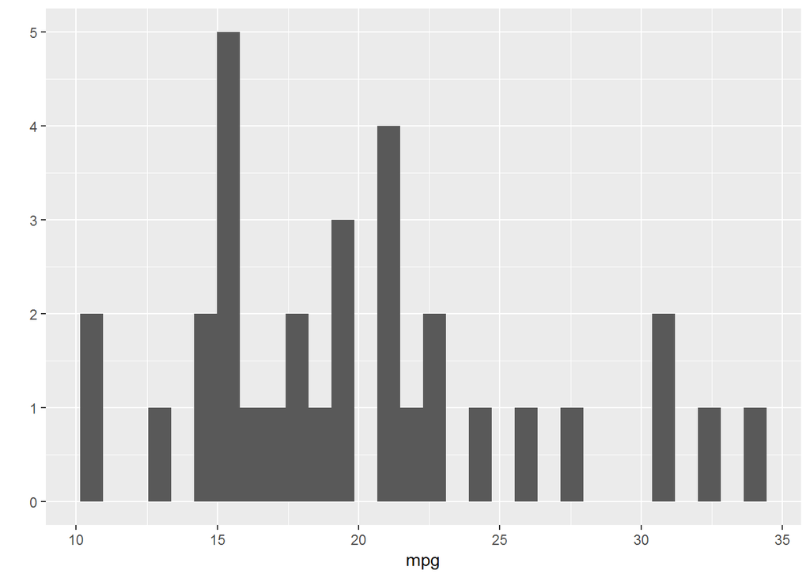

```r
qplot(mpg, data = readRDS(here("data", "processed", "mtcars_df.Rds")))
```

#### Scatterplot of mpg and wt in mtcars

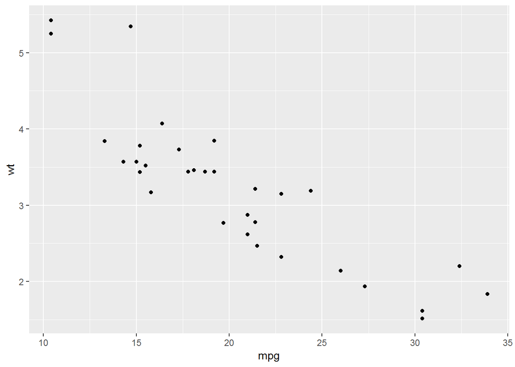

```r
qplot(mpg, wt, data = readRDS(here("data", "processed", "mtcars_df.Rds")))
```

#### Table of summary statistics of mtcars

Note that we have to turn on html and results=‘asis’ to get the pretty output in html

```r
stargazer(readRDS(here("data", "processed", "mtcars_df.rds")), type = "html")
```

| Statistic | N | Mean | St. Dev. | Min | Pctl(25) | Pctl(75) | Max |
| --- | --- | --- | --- | --- | --- | --- | --- |
| mpg | 32 | 20.091 | 6.027 | 10 | 15.4 | 22.8 | 34 |
| cyl | 32 | 6.188 | 1.786 | 4 | 4 | 8 | 8 |
| disp | 32 | 230.722 | 123.939 | 71 | 120.8 | 326 | 472 |
| hp | 32 | 146.688 | 68.563 | 52 | 96.5 | 180 | 335 |
| drat | 32 | 3.597 | 0.535 | 2.760 | 3.080 | 3.920 | 4.930 |
| wt | 32 | 3.217 | 0.978 | 1.513 | 2.581 | 3.610 | 5.424 |
| qsec | 32 | 17.849 | 1.787 | 14.500 | 16.892 | 18.900 | 22.900 |
| vs | 32 | 0.438 | 0.504 | 0 | 0 | 1 | 1 |
| am | 32 | 0.406 | 0.499 | 0 | 0 | 1 | 1 |
| gear | 32 | 3.688 | 0.738 | 3 | 3 | 4 | 5 |
| carb | 32 | 2.812 | 1.615 | 1 | 2 | 4 | 8 |

### Other alternativers

#### Relative file paths in Markdown and loading existing image

Since we have created an image file we can use relative path and load it directly. Note that Markdown uses the folder the markdown file is saved in as working directory, and NOT the directory of the RProject. This is in contrast to the R-code, which starts out with the project directory. In this case the report is in its own folder called ‘reports’, meaning we must up a level and down to figures. Note that this file is a png, and that this does not scale well and can be cumbersome with for instance a presentation. It is however easy to choose different formats. Note that this is not a code chunk, but written directly in Markdown.

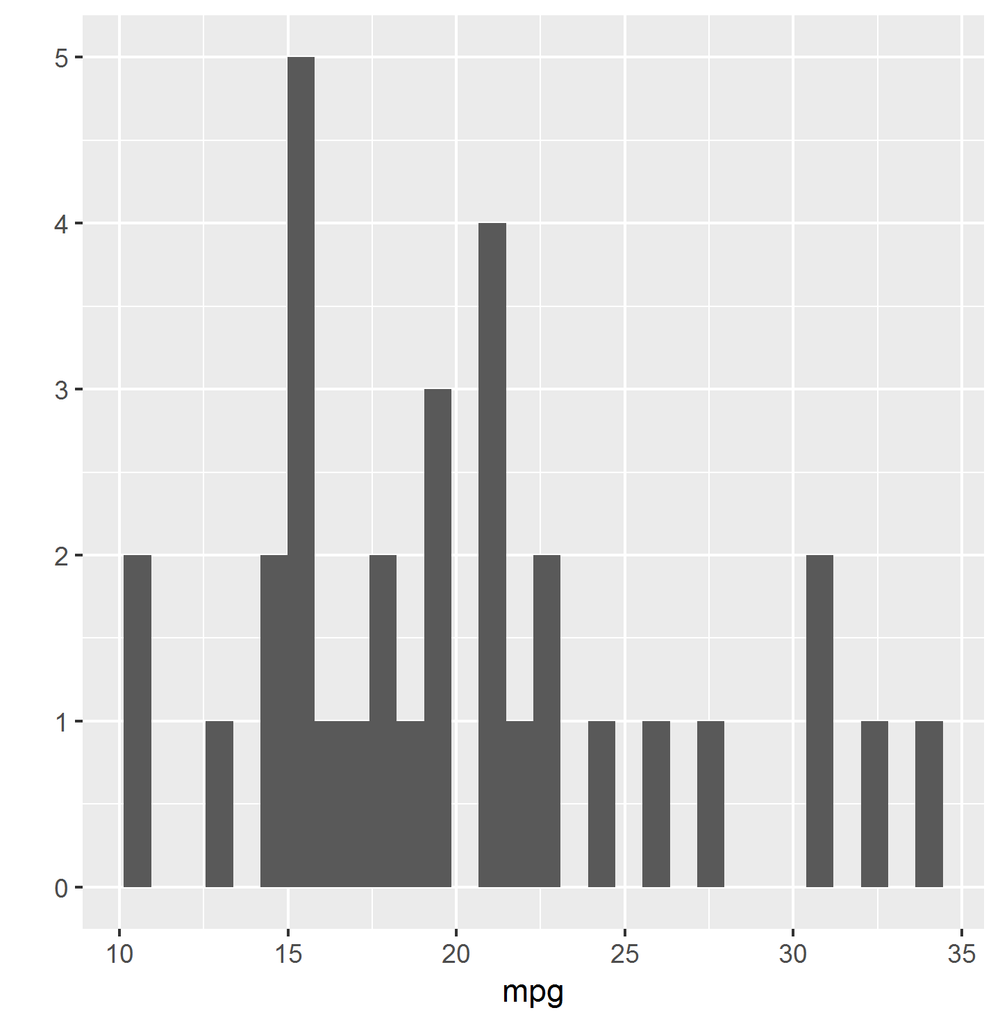

Heading of your choice

#### Adding an existing table by copy pasting the html output

When we ran the stargazer command in the script create_table_example.R, the console produced the html code. You can simply copy paste that code right into Markdown, but this creates messy code (but good output). I have to date not found an easy way to load the saved html file using relative links as I did with the image.

| Statistic | N | Mean | St. Dev. | Min | Pctl(25) | Pctl(75) | Max |
| --- | --- | --- | --- | --- | --- | --- | --- |
| mpg | 32 | 20.091 | 6.027 | 10 | 15.4 | 22.8 | 34 |
| cyl | 32 | 6.188 | 1.786 | 4 | 4 | 8 | 8 |
| disp | 32 | 230.722 | 123.939 | 71 | 120.8 | 326 | 472 |
| hp | 32 | 146.688 | 68.563 | 52 | 96.5 | 180 | 335 |
| drat | 32 | 3.597 | 0.535 | 2.760 | 3.080 | 3.920 | 4.930 |
| wt | 32 | 3.217 | 0.978 | 1.513 | 2.581 | 3.610 | 5.424 |
| qsec | 32 | 17.849 | 1.787 | 14.500 | 16.892 | 18.900 | 22.900 |
| vs | 32 | 0.438 | 0.504 | 0 | 0 | 1 | 1 |
| am | 32 | 0.406 | 0.499 | 0 | 0 | 1 | 1 |
| gear | 32 | 3.688 | 0.738 | 3 | 3 | 4 | 5 |
| carb | 32 | 2.812 | 1.615 | 1 | 2 | 4 | 8 |

[figure not shown]

Heading of your choice